# Exam 2, Spring 2024

Alina Valliani

DATA 2401

# Instructions

This exam is covered by the **UHD honor code**. Turning in this exam acknowledges that all work submitted on this exam is your own, and that you have not used any off limit resource. You may use the R help files and your notes as needed.

Be sure to commit your rmd *and* your knitted results to GitHub.

You are submitting this exam under the UHD honor code. Answer all below questions on the `Exam2_template_S24.Rmd` provided on Github. Complete the questions, knit the file to html, commit and push to your repository *BEFORE 1:15*. **Any commit that is pushed after 1:15 will not be graded.**

Code clarity and organization will be 5 points of your total grade. Make sure you have comments where needed and your code is easy to follow (and grade), do not print out whole dataframes. Please read this document carefully to make sure that you don’t miss any requested task.

# 0 - Loading in Data

Use this code to read in your data.

AKCdata is data about 136 breeds of dogs, from the American Kennel Club. There are variables with missing data.

```r
AKCdata <- read_csv("https://raw.githubusercontent.com/kshoemaker/Exam2Data/main/best_in_show.csv", show_col_types = F, na = c("", "no data","-")) %>%
  mutate(intelligence_category = factor(intelligence_category, levels = c("Unknown", "Lowest", "Fair", "Average", "Above average", "Excellent", "Brightest"), ordered = T, exclude = NULL),
         Suitability_for_Children = factor(Suitability_for_Children, levels = c("Unknown", "Low", "Medium", "High"), ordered = T, exclude = NULL))

sizedata <- read_csv("https://raw.githubusercontent.com/kshoemaker/Exam2Data/main/DogSize.csv", show_col_types = F)
```

# 1 - Dog Info - EDA using dplyr and ggplot

We will start with `AKCdata`, information about dog breeds from the American Kennel Club.

```r
glimpse(AKCdata)
```

```
## Rows: 136
## Columns: 11
## $ Dog_breed                <chr> "Portuguese Water Dog", "Finnish Lapphund", "…
## $ category                 <chr> "working", "herding", "terrier", "working", "…
## $ Popularity               <dbl> 56, 104, 106, 111, 112, 141, 142, 150, 152, 1…
## $ INTELLIGENCE_ranking     <dbl> NA, NA, NA, NA, 34, 34, 47, 24, NA, 41, NA, N…
## $ Average_Lifetime         <dbl> 11.42, 7.33, 8.42, 10.75, 12.77, 9.90, 8.70, …
## $ Suitability_for_Children <ord> Unknown, Low, Low, Medium, Low, Medium, Unkno…
## $ size_category            <chr> "medium", "medium", "small", "large", "medium…
## $ intelligence_category    <ord> Unknown, Unknown, Unknown, Unknown, Above ave…
## $ Average_Price            <dbl> NA, NA, NA, NA, NA, NA, NA, NA, NA, NA, NA, N…
## $ price_bracket            <chr> "Unknown", "Unknown", "Unknown", "Unknown", "…
## $ Food_cost_per_year       <dbl> NA, NA, NA, NA, NA, NA, NA, NA, NA, NA, NA, N…
```

Using dplyr and the data, answer the following questions:

- (1.1) What are the 10 most popular dogs? The 10 most intelligent dogs? A quick note: For both `Popularity` and `INTELLIGENCE_ranking`, 1 is the highest ranking, so the most popular dog will have Popularity of 1.

```r
AKCdata %>% arrange(Popularity) %>% slice(1:10)
```

```
## # A tibble: 10 × 11
##    Dog_breed          category  Popularity INTELLIGENCE_ranking Average_Lifetime
##    <chr>              <chr>          <dbl>                <dbl>            <dbl>
##  1 Labrador Retriever sporting           1                    7            12.0
##  2 German Shepherd    herding            2                    3             9.73
##  3 Beagle             hound              3                   73            12.3
##  4 Golden Retriever   sporting           4                    4            12.0
##  5 Yorkshire Terrier  toy                5                   27            12.6
##  6 Bulldog            non-spor…          6                   78             6.29
##  7 Boxer              working            7                   48             8.81
##  8 Poodle             non-spor…          8                    2            12.0
##  9 Dachshund          hound              9                   49            12.6
## 10 Rottweiler         working           10                    9             9.11
## # ℹ 6 more variables: Suitability_for_Children <ord>, size_category <chr>,
## #   intelligence_category <ord>, Average_Price <dbl>, price_bracket <chr>,
## #   Food_cost_per_year <dbl>
```

```r
AKCdata %>% arrange(INTELLIGENCE_ranking) %>% slice(1:10)
```

```
## # A tibble: 10 × 11
##    Dog_breed           category Popularity INTELLIGENCE_ranking Average_Lifetime
##    <chr>               <chr>         <dbl>                <dbl>            <dbl>
##  1 Border Collie       herding          45                    1            12.5
##  2 Poodle              non-spo…          8                    2            12.0
##  3 German Shepherd     herding           2                    3             9.73
##  4 Golden Retriever    sporting          4                    4            12.0
##  5 Doberman Pinscher   working          13                    5            10.3
##  6 Shetland Sheepdog   herding          20                    6            12.5
##  7 Labrador Retriever  sporting          1                    7            12.0
##  8 Papillon            toy              38                    8            13
##  9 Rottweiler          working          10                    9             9.11
## 10 Australian Cattle … herding          60                   10            11.7
## # ℹ 6 more variables: Suitability_for_Children <ord>, size_category <chr>,
## #   intelligence_category <ord>, Average_Price <dbl>, price_bracket <chr>,
## #   Food_cost_per_year <dbl>
```

- (1.2) What are the 5 dogs with the longest `average_lifetime`?

```r
AKCdata %>% arrange(-Average_Lifetime) %>% slice (1:5)
```

```
## # A tibble: 5 × 11
##   Dog_breed        category     Popularity INTELLIGENCE_ranking Average_Lifetime
##   <chr>            <chr>             <dbl>                <dbl>            <dbl>
## 1 Chihuahua        toy                  14                   67             16.5
## 2 Canaan Dog       herding             168                   NA             14.7
## 3 Tibetan Spaniel  non-sporting        114                   46             14.4
## 4 Silky Terrier    toy                  85                   37             14.2
## 5 Swedish Vallhund herding             153                   NA             14.2
## # ℹ 6 more variables: Suitability_for_Children <ord>, size_category <chr>,
## #   intelligence_category <ord>, Average_Price <dbl>, price_bracket <chr>,
## #   Food_cost_per_year <dbl>
```

- (1.3) What is the dog breed with the longest average lifetime in each `category`?

```r
AKCdata %>%
  group_by(category) %>%
  summarise(mean(Average_Lifetime))
```

```
## # A tibble: 7 × 2
##   category     `mean(Average_Lifetime)`
##   <chr>                           <dbl>
## 1 herding                         11.7
## 2 hound                           10.8
## 3 non-sporting                    11.0
## 4 sporting                        10.9
## 5 terrier                         11.5
## 6 toy                             11.7
## 7 working                          9.13
```

- (1.4) Suppose I’m interested in dogs with “High” `Suitability_for_Children` and that live a long time. Use this data to find the ideal dogs for me.

```r
numdog_suggest = 3

AKCdata %>% filter(Suitability_for_Children =="High") %>%
  arrange(-Average_Lifetime) %>%
  slice(1:numdog_suggest)
```

```
## # A tibble: 3 × 11
##   Dog_breed         category Popularity INTELLIGENCE_ranking Average_Lifetime
##   <chr>             <chr>         <dbl>                <dbl>            <dbl>
## 1 Chihuahua         toy              14                   67             16.5
## 2 Dachshund         hound             9                   49             12.6
## 3 Yorkshire Terrier toy               5                   27             12.6
## # ℹ 6 more variables: Suitability_for_Children <ord>, size_category <chr>,
## #   intelligence_category <ord>, Average_Price <dbl>, price_bracket <chr>,
## #   Food_cost_per_year <dbl>
```

- (1.5) How many types of dogs are in each `category`?

```r
AKCdata %>%
  group_by(category) %>%
  summarize(count = n()) %>%
  arrange(-count)
```

```
## # A tibble: 7 × 2
##   category     count
##   <chr>        <int>
## 1 sporting        25
## 2 working         23
## 3 terrier         22
## 4 herding         17
## 5 hound           17
## 6 toy             17
## 7 non-sporting    15
```

- (1.6) What is the average purchase price and the average popularity ranking for each category of dogs? Use the variables `Average_Price` and `Popularity`. Arrange your results by average price.

```r
AKCdata %>%
  group_by(category) %>%
  summarise(mean_Average_Price = mean(Average_Price, na.rm = TRUE), mean_Popularity = mean(Popularity, na.rm = TRUE)) %>%
  arrange(-mean_Average_Price)
```

```
## # A tibble: 7 × 3
##   category     mean_Average_Price mean_Popularity
##   <chr>                     <dbl>           <dbl>
## 1 working                   1237.            65.4
## 2 non-sporting               982.            71.4
## 3 terrier                    911.            99.2
## 4 hound                      790.            85.1
## 5 sporting                   782.            84.8
## 6 herding                    756.            89.3
## 7 toy                        709.            52
```

- (1.7) Create an appropriate graph that looks at the *distribution* of the `Average_Price` of all the dogs.

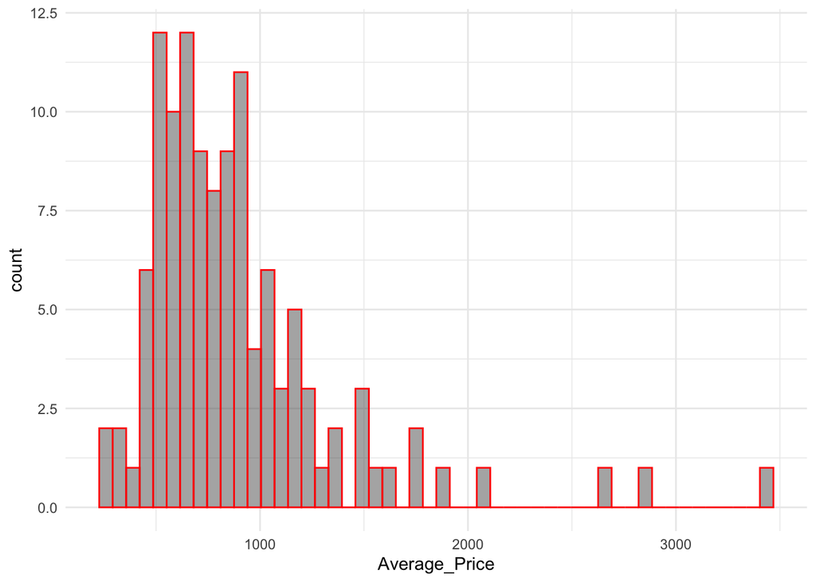

```r
AKCdata %>% ggplot(aes(x= Average_Price)) +
  geom_histogram(bins = 50, color= "red",  alpha = 0.5, position = 'identity') +
  theme_minimal()
```

- (1.8) Now, do the same idea again, but filter the data to the most expensive and least expensive two categories (on average). Color or facet the graph by categories.

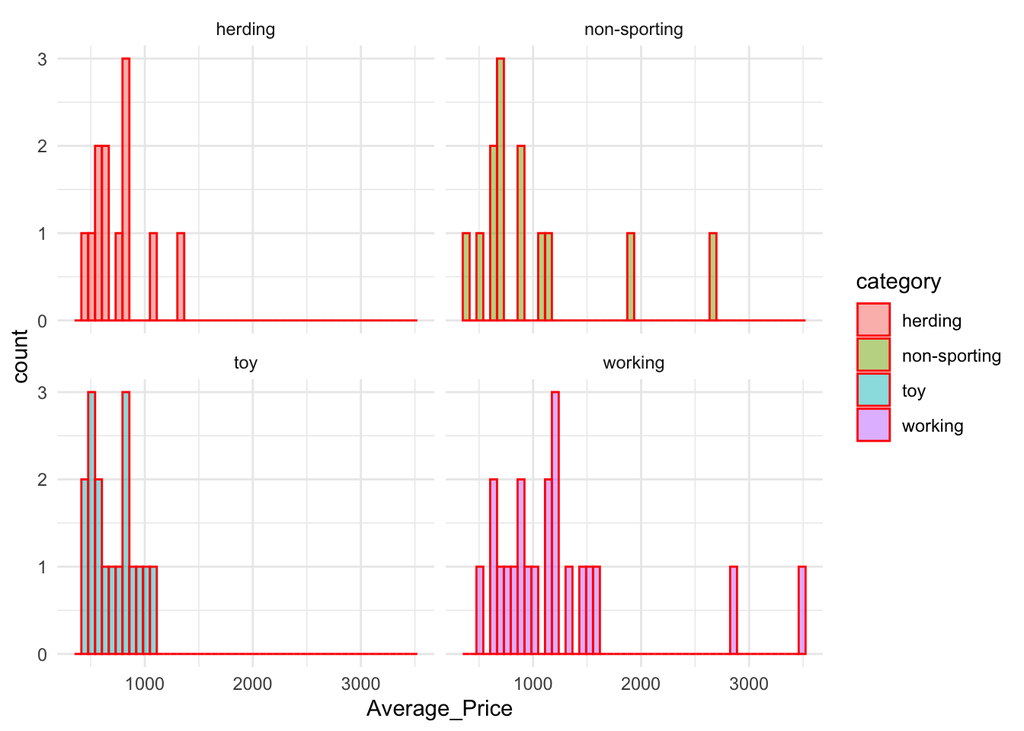

```r
category_summary <- AKCdata %>% group_by(category) %>%
  mutate(avg_price = mean(Average_Price,na.rm = TRUE)) %>% arrange(avg_price)

most_expensive_category <- tail(unique(category_summary$category), 2)
least_expensive_category <- head(unique(category_summary$category), 2)

AKCdata %>% filter(category %in% c(most_expensive_category, least_expensive_category))%>%
  ggplot(aes(x = Average_Price, fill = category)) +
  geom_histogram(bins = 50, color = "red", alpha = 0.5, position = "identity") +
  facet_wrap(~category) +
  theme_minimal()
```

# 2 - Relationships

Go back to the unfiltered AKCdata to answer the following questions about relationships in the data.

- (2.1) Is there a relationship between the `Popularity` and the `Average_Price`? Use an appropriate plot to investigate visually.

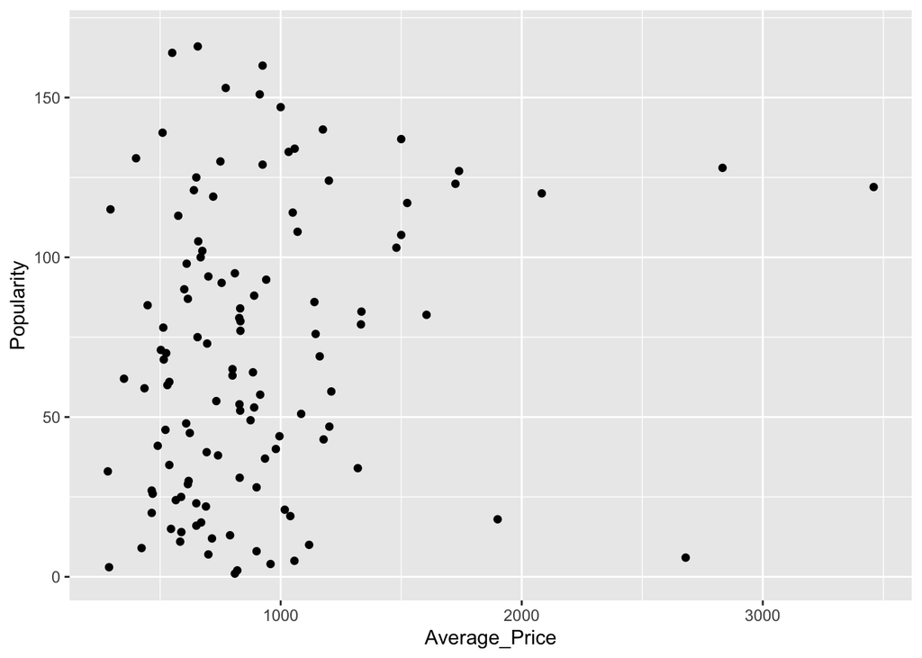

```r
AKCdata %>%
  ggplot() +
  aes(x = Popularity,
      y = Average_Price) +
  geom_point() +
  coord_flip()
```

- (2.2) Looks like there are some outliers in price - What are the top 10 most expensive breeds? Make it so that your result table only shows `Dog_breed`, `category`, `Popularity` and `Average_Price`

```r
AKCdata %>%
  arrange(-Average_Price) %>%
  select(Dog_breed, category, Popularity, Average_Price) %>%
  head(10)
```

```
## # A tibble: 10 × 4
##    Dog_breed                          category     Popularity Average_Price
##    <chr>                              <chr>             <dbl>         <dbl>
##  1 Tibetan Mastiff                    working             122          3460
##  2 Black Russian Terrier              working             128          2833
##  3 Bulldog                            non-sporting          6          2680
##  4 Norfolk Terrier                    terrier             120          2083
##  5 French Bulldog                     non-sporting         18          1900
##  6 Miniature Bull Terrier             terrier             127          1740
##  7 Spinone Italiano                   sporting            123          1725
##  8 Greater Swiss Mountain Dog         working              82          1605
##  9 Saluki                             hound               117          1525
## 10 Nova Scotia Duck Tolling Retriever sporting            107          1500
```

- (2.3) How many dog breeds are in each `intelligence_category`? You may answer with a summary table or with an appropriate graph.

```r
AKCdata %>%
  group_by(intelligence_category) %>%
  summarize(count = n())
```

```
## # A tibble: 7 × 2
##   intelligence_category count
##   <ord>                 <int>
## 1 Unknown                  24
## 2 Lowest                   11
## 3 Fair                     21
## 4 Average                  30
## 5 Above average            24
## 6 Excellent                16
## 7 Brightest                10
```

- (2.4) What is the relationship between `category` and `intelligence_category`? Use an appropriate graph to look.

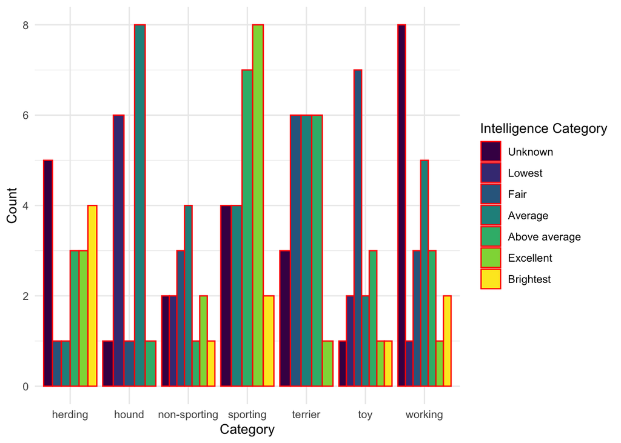

```r
ggplot(AKCdata, aes(x = category, fill = intelligence_category)) +
  geom_bar(position = "dodge", color = "red", stat = "count") +
  labs(x = "Category", y = "Count", fill = "Intelligence Category") +
  theme_minimal()
```

- (2.5) Is there a relationship between `category`, `Popularity` and the `Intelligence_ranking`? Use an appropriate plot to find out.

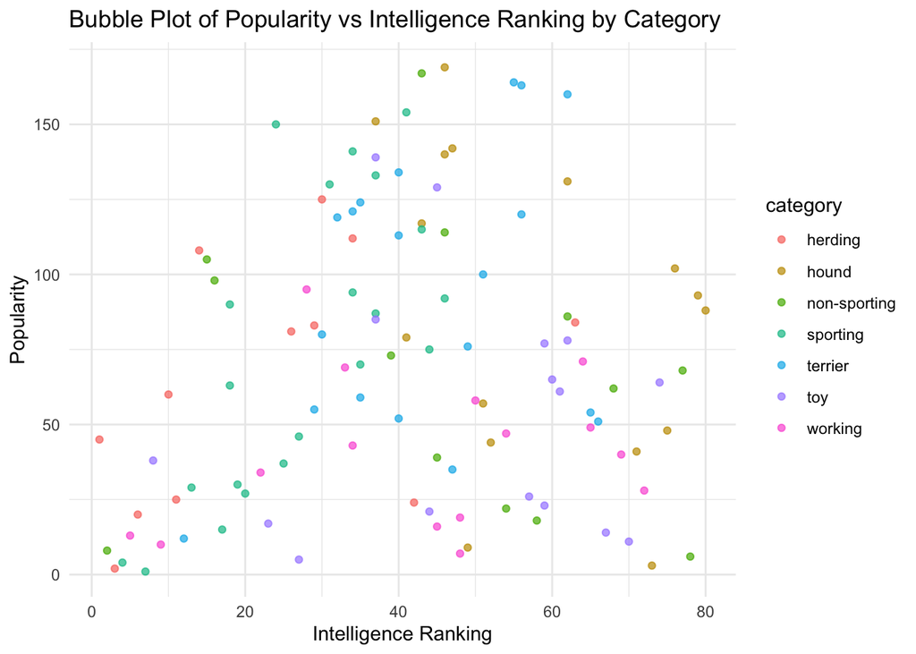

```r
AKCdata_filtered <- AKCdata[!is.na(AKCdata$INTELLIGENCE_ranking), ]

bubble_plot <- ggplot(AKCdata_filtered, aes(x = INTELLIGENCE_ranking, y = Popularity, color = category)) +
  geom_point(alpha = 0.7) +
  scale_size_continuous(range = c(3, 10)) +
  labs(x = "Intelligence Ranking", y = "Popularity", title = "Bubble Plot of Popularity vs Intelligence Ranking by Category") +
  theme_minimal()

bubble_plot
```

# 3 - New Variable for Total Costs

We have the average purchase price of the dog, `Average_Price`, the average lifetime of the dog, `Average_Lifetime`, and the food cost per year, `Food_cost_per_year`. If we’re interested in the lifetime cost of the dog, we can find that!

(3.1) Create a new column in your dataframe called `Total_cost` that adds together the `Average_Price` of the dog breed and the `Food_cost_per_year` times the `Average_Lifetime` of that breed. Be sure to add it to your dataframe.

```r
AKCdata <- AKCdata %>%
  mutate(Total_cost = Average_Price + Food_cost_per_year * Average_Lifetime)
```

(3.2) Let’s check again now that we have this total cost value - is there a relationship between `Total_cost` and `Popularity`?

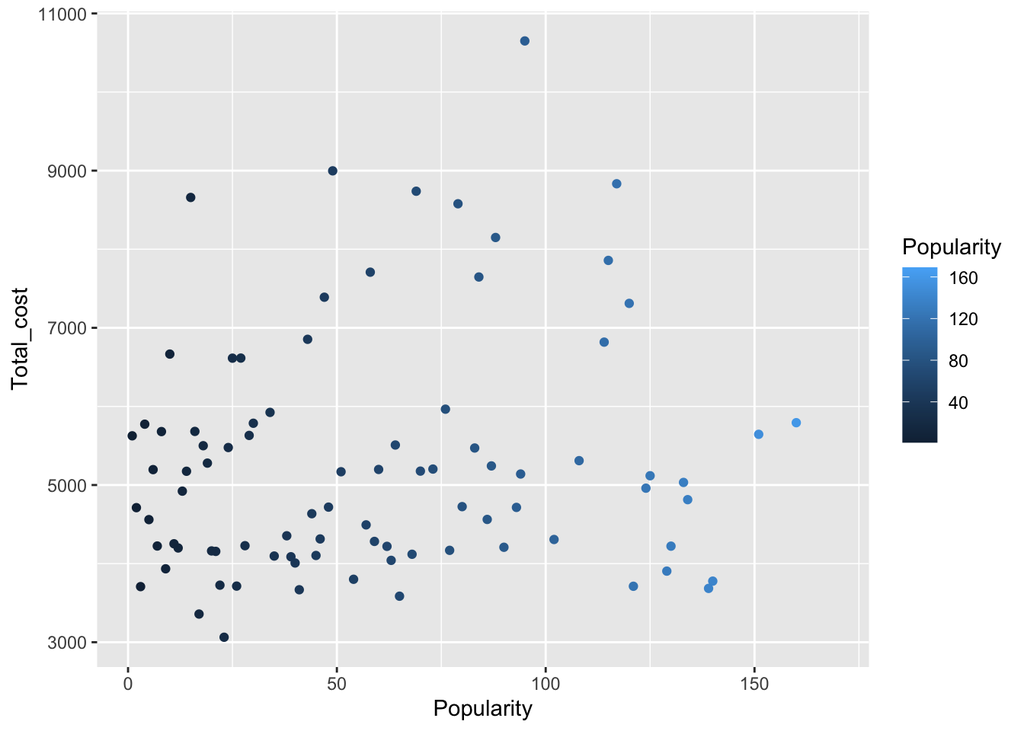

```r
AKCdata %>% ggplot(aes(x= Popularity, y = Total_cost, color = Popularity)) +
  geom_point()
```

# 4 - Join in the size info

The AKC data has a size category, but nothing about their height and weight specifically. Most of the dog breeds have their sizes listed in the second “sizedata” dataframe.

(4.1) Using a join, combine the size info with the AKCdata. We are only interested in dog breeds that have AKC data *and* size data at this point, so consider the correct join to use.

```r
combine_AKCdata <- left_join(AKCdata, sizedata, by = c("Dog_breed"="Breed"))
combine_AKCdata
```

```
## # A tibble: 136 × 18
##    Dog_breed           category Popularity INTELLIGENCE_ranking Average_Lifetime
##    <chr>               <chr>         <dbl>                <dbl>            <dbl>
##  1 Portuguese Water D… working          56                   NA            11.4
##  2 Finnish Lapphund    herding         104                   NA             7.33
##  3 Cesky Terrier       terrier         106                   NA             8.42
##  4 Anatolian Shepherd… working         111                   NA            10.8
##  5 Bearded Collie      herding         112                   34            12.8
##  6 Field Spaniel       sporting        141                   34             9.9
##  7 Scottish Deerhound  hound           142                   47             8.7
##  8 Irish Water Spaniel sporting        150                   24             9.33
##  9 Löwchen             non-spo…        152                   NA            10
## 10 Curly Coated Retri… sporting        154                   41            10.8
## # ℹ 126 more rows
## # ℹ 13 more variables: Suitability_for_Children <ord>, size_category <chr>,
## #   intelligence_category <ord>, Average_Price <dbl>, price_bracket <chr>,
## #   Food_cost_per_year <dbl>, Total_cost <dbl>, height_low_inches <dbl>,
## #   height_avg_inches <dbl>, height_high_inches <dbl>, weight_low_lbs <dbl>,
## #   weight_avg_lbs <dbl>, weight_high_lbs <dbl>
```

(4.2) It is said that small dogs live longer. Choose an appropriate tool (or tools) to investigate the relationship between size and average lifetime. You may use any of the variables available to you.

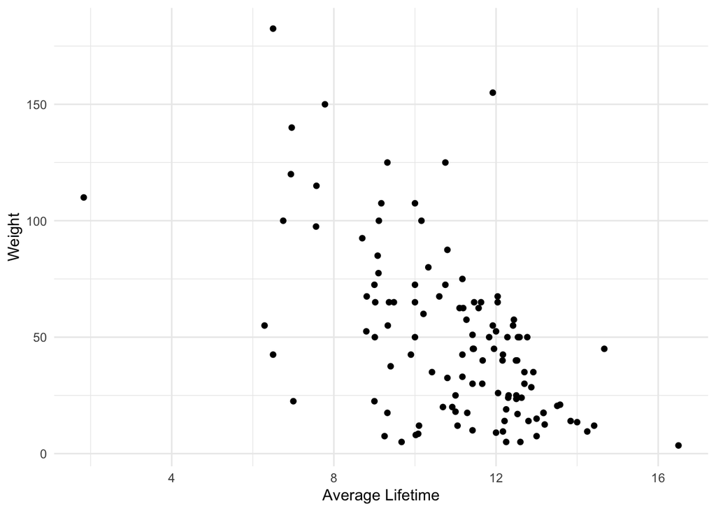

```r
ggplot(combine_AKCdata, aes(x = Average_Lifetime , y = weight_avg_lbs)) +
  geom_point() +
  labs(x = "Average Lifetime", y = "Weight") +
  theme_minimal()
```

# 5 - Your Turn

**Using one or both of these dataframes of dogs, state a question and create a plot (or plots) of your own to answer that question.** You may use the original dataframes, the filtered dataframes, the joined dataframe, or any combination of your choice.

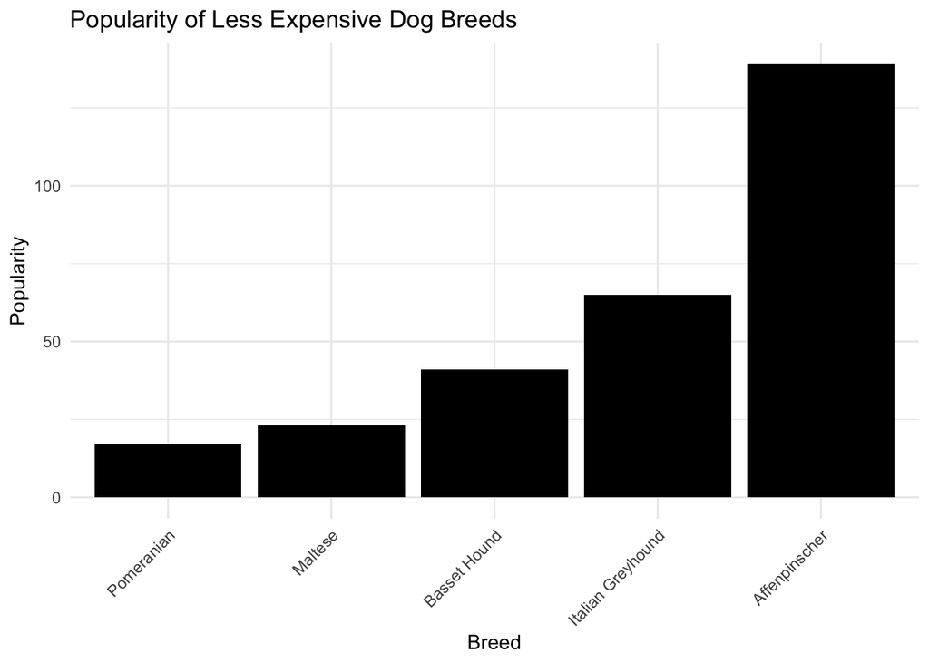

```r
less_expensive_popular <- AKCdata %>% na.omit() %>%
  arrange(Total_cost) %>%
  slice_head(n = 5)

# Create a bar plot to visualize the popularity of less expensive dog breeds
ggplot(less_expensive_popular, aes(x = reorder(Dog_breed, Popularity), y = Popularity)) +
  geom_bar(stat = "identity", fill = "black") +
  labs(x = "Breed", y = "Popularity", title = "Popularity of Less Expensive Dog Breeds") +
  theme_minimal() +
  theme(axis.text.x = element_text(angle = 45, hjust = 1))
```